# Assignment

2022

**Attaching the data**

```r
load("C:/Users/PascalPC/Desktop/datasets_sheet1.RData")
```

# 1 1st Question

## 1.2 (b)

We know that the density function of a normal variable is:

$X \sim N(\mu , \sigma^{2}) \longrightarrow f_X (x)=\frac{1}{\sqrt{2\pi \sigma^{2}}} e^{-\dfrac{(x-\mu)^{2}}{2\sigma^{2}}}$

Likelihood for the i-th individual, using the above density and the given function for $\mu$ , can be written as

$L_i (\theta_{1} , \theta_{2}, \sigma^{2})=\frac{1}{\sqrt{2\pi \sigma^{2}}} e^{-\dfrac{(y_i - \frac{\theta_{1}x_i}{\theta_{2}+x_i})^{2}}{2\sigma^{2}}}$.

Also, we know that the full likelihood is the product of the likelihood for individuals, having the mathematical relation as

$L (\theta_{1} , \theta_{2}, \sigma^{2})= \prod_{i=1}^{n}{L_i (\theta_{1} , \theta_{2}, \sigma^{2})}$.

Thus, in this example, as we know that $n=100$, we have:

$L (\theta_{1} , \theta_{2}, \sigma^{2})=(2\pi \sigma^{2})^{-\dfrac{100}{2}} e^{-\dfrac{\sum_{i=1}^{100} (y_i - \frac{\theta_{1}x_i}{\theta_{2}+x_i})^{2}}{2\sigma^{2}}}$.

Taking logarithm from the obtained equation gives the equation for log-likelihood:

$l (\theta_{1} , \theta_{2}, \sigma^{2})=-\dfrac{100}{2}log(2\pi \sigma^{2}) {-\dfrac{\sum_{i=1}^{100}(y_i-\frac{\theta_{1}x_i}{\theta_{2}+x_i})^{2}}{2\sigma^{2}}}$

## 1.3 (c)

```r
############################
mylike = function(p,data){
    theta_1=p[1]
    theta_2=p[2]
    sigma_squared = p[3]
    x=data$x
    y=data$y
    n = dim(data)[1]
    n/2*log(2*pi*sigma_squared)+sum((y-(theta_1*x/(theta_2+x)))^2)/(2*sigma_squared)
}
```

Calling the function for an arbitrary value

```r
mylike(c(30, -0.1858 , 940) , nlmodel)
```

```
## [1] 1739.501
```

## 1.4 (d)

```r
Estimates = nlm(mylike , p = c(214 , 0.06 , 185),nlmodel , typsize = c(0.001 , 0.1 ,0.1) , gradtol = 1e-10 , hessian = T) ;Estimates
```

```
## $minimum
## [1] 403.0458
##
## $estimate
## [1] 214.00000000   0.06254782 185.00000005
##
## $gradient
## [1] -0.0922293948  0.0001193712 -0.0007251629
##
## $hessian
##               [,1]          [,2]          [,3]
## [1,]  3.841641e-01 -1.596051e+02  0.0004764924
## [2,] -1.596051e+02  1.057527e+05 -0.0028308023
## [3,]  4.764924e-04 -2.830802e-03  0.0014681747
##
## $code
## [1] 2
##
## $iterations
## [1] 5
```

We start by choosing an arbitrary value as starting points, and look at the given code in the output (which should be either $1$ or $2$) and tend to change starting values with the computed estimates in the first iteration. We do this process until the gradient values are really small, the code is close to $1$ and estimated values are stable.

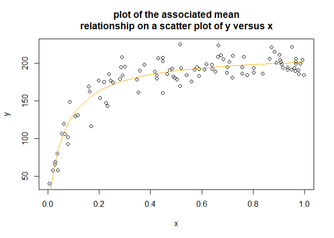

```r
df=data.frame(x=nlmodel$x,y=nlmodel$y)
df$mu=Estimates$estimate[1]*nlmodel$x/(Estimates$estimate[2]+nlmodel$x)
df <-df[order(df$x),]
plot(df$x, df$y, xlab="x", ylab="y", main="plot of the associated mean
relationship on a scatter plot of y versus x")
lines(df$x,df$mu, col="orange", type="l")
```

## 1.5 (e)

```r
library(HelpersMG)
library(knitr)
SE = SEfromHessian(Estimates$hessian)
SE.mat = data.frame( SE_theta1 = SE[1] , SE_theta2 = SE[2])
CI = data.frame(CItheta1 = paste0("(",round(Estimates$estimate[1]-pnorm(0.975)*SE[1],3),", ",(round(Estimates$estimate[1]+pnorm(0.975)*SE[1],3)),")"),
                CItheta2 = paste0("(",round(Estimates$estimate[2]-pnorm(0.975)*SE[2],3),", ",(round(Estimates$estimate[2]+pnorm(0.975)*SE[2],3)),")"))

kable(SE.mat, col.names = c("$SE(\\theta_1)$", "$SE(\\theta_2)$"),escape = FALSE , caption = "Table of standard errors for $\\theta_1$ and $\\theta_2$")
```

Table of standard errors for $\theta_1$ and $\theta_2$

| $SE(\theta_1)$ | $SE(\theta_2)$ |
| --- | --- |
| 2.643214 | 0.0050368 |

```r
kable(CI , col.names = c("$CI(\\theta_1)$", "$CI(\\theta_2)$"),escape = FALSE , caption = "Table of Confidence Intervals for $\\theta_1$ and $\\theta_2$")
```

Table of Confidence Intervals for $\theta_1$ and $\theta_2$

| $CI(\theta_1)$ | $CI(\theta_2)$ |
| --- | --- |
| (211.792, 216.208) | (0.058, 0.067) |

## 1.6 (f)

```r
pvalue_calc = function(given_value , testfor = c(1,2,3) , alpha = 0.05){
  p_value = 2*min(pnorm(as.numeric(Estimates$estimate[testfor]-given_value)/SE[testfor],lower.tail = F) , pnorm(as.numeric(Estimates$estimate[testfor]-given_value)/SE[testfor]))
  if(p_value>alpha){cat('The true value is about ' , given_value, ' with a pvalue of ' , p_value )}
  else{cat('The true value is not about ' , given_value, ' with a pvalue of ' , p_value )}
}
pvalue_calc( 0.08, 2)
```

```
## The true value is not about  0.08  with a pvalue of  0.0005304054
```

## 1.7 (g)

First, we fit a non-linear model using package $gnm$.

```r
func <- function(x){
list(predictors =list(theta_1 = 1, theta_2 = 1),
variables = list(substitute(x)),
term = function(predLabels, varLabels) {
paste(predLabels[1],"*",varLabels[1], "/","(", predLabels[2], "+",
varLabels[1],")")
})
}
class(func) <- "nonlin"

#install.packages("gnm")
library("gnm")
model=gnm(formula =y ~ func(x)-1,family = gaussian , data = nlmodel)
```

```
## Initialising
## Running start-up iterations..
## Running main iterations.....
## Done
```

```r
summary(model)
```

```
##
## Call:
## gnm(formula = y ~ func(x) - 1, family = gaussian, data = nlmodel)
##
## Deviance Residuals:
##      Min        1Q    Median        3Q       Max
## -39.7529   -8.9289    0.3243    8.3465   33.9811
##
## Coefficients:
##          Estimate Std. Error t value Pr(>|t|)
## theta_1 214.65004    2.70862   79.25   <2e-16 ***
## theta_2   0.06353    0.00521   12.19   <2e-16 ***
## ---
## Signif. codes:  0 '***' 0.001 '**' 0.01 '*' 0.05 '.' 0.1 ' ' 1
##
## (Dispersion parameter for gaussian family taken to be 189.1692)
##
## Residual deviance: 18539 on 98 degrees of freedom
## AIC: 812.03
##
## Number of iterations: 5
```

As can be seen, $coefficient$ and their $SE$ are almost the same as the method used by $nlm$

Then we construct a $95 \%$ prediction interval:

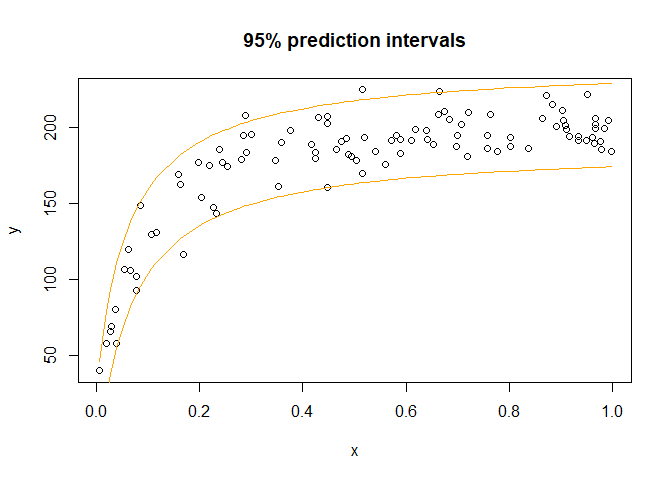

```r
#install.packages("ciTools")
library(ciTools)
x = nlmodel$x
y = nlmodel$y
dat <- data.frame(x = x, y = y)
dat1 <- add_pi(dat, model, names = c("lpb", "upb"), alpha = 0.05, nsims = 20000)
dat1 <-dat1[order(dat1$x),]
plot(dat1$x, dat1$y, xlab="x", ylab="y", main="95% prediction intervals")
lines(dat1$x, dat1$lpb, col="orange",type="l")
lines(dat1$x,dat1$upb, col="orange", type="l")
```

# 2 2nd Question

## 2.1 (a)

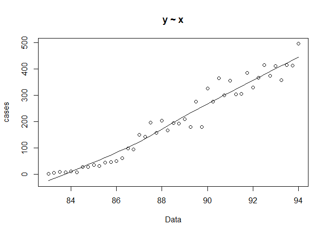

```r
y=aids$cases; x=aids$date
scatter.smooth(x=x, y=y, main="y ~ x" , xlab = 'Data' , ylab = 'cases')
```

**For the $poisson$ model**

There are several problems if you try to apply linear regression for this kind of data.

1. The relationship between $X$ and $Y$ does not look linear. It’s more likely to be exponential.
2. The variance of $Y$ does not look constant with regard to $X$. Here, the variance of $Y$ seems to increase when $X$ increases.

**For the $Gaussian$ model**

From the plot, it’s obvious that as $x$ values increase, values on the $y$ axis increase exponentially. Thus, we have to model the mean with an $exp$ transform, or equivalently $log(\mu_i) = \gamma_0 + \gamma_1*x_i$

## 2.2 (b)

```r
model1 = glm(y~x,family = poisson(link = 'log'))
model2 = glm(y~x,family = gaussian(link = 'log'))
```

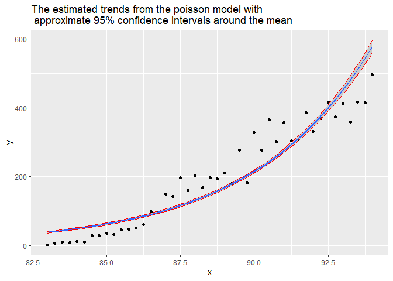

```r
library(ggplot2)
my_data=data.frame(x=x,y=y)
preddata <- with(my_data, data.frame(x = seq(min(x), max(x), length = 100)))
preds <- predict(model1, newdata = preddata, type = "link", se.fit = TRUE)
critval <- 1.96 ## approx 95% CI
upr <- preds$fit + (critval * preds$se.fit)
lwr <- preds$fit - (critval * preds$se.fit)
fit <- preds$fit

fit1 <- model1$family$linkinv(fit)
upr1 <- model1$family$linkinv(upr)
lwr1 <- model1$family$linkinv(lwr)



preddata$lwr <- lwr1
preddata$upr <- upr1
ggplot(data=my_data, mapping=aes(x=x,y=y)) + geom_point() +
  stat_smooth(method="glm", method.args=list(family='poisson')) +
  geom_line(data=preddata, mapping=aes(x=x, y=upr), col="red") +
  geom_line(data=preddata, mapping=aes(x=x, y=lwr), col="red") + ggtitle('The estimated trends from the poisson model with \n approximate 95% confidence intervals around the mean')
```

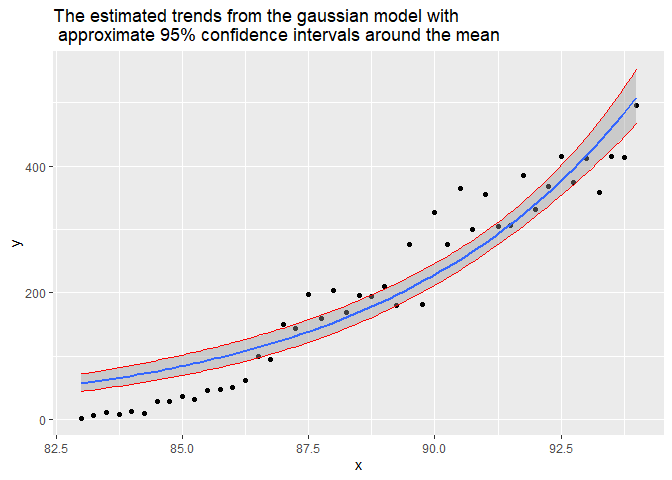

```r
my_data=data.frame(x=x,y=y)
preddata <- with(my_data, data.frame(x = seq(min(x), max(x), length = 100)))
preds <- predict(model2, newdata = preddata, type = "link", se.fit = TRUE)
critval <- 1.96 ## approx 95% CI
upr <- preds$fit + (critval * preds$se.fit)
lwr <- preds$fit - (critval * preds$se.fit)
fit <- preds$fit

fit2 <- model2$family$linkinv(fit)
upr2 <- model2$family$linkinv(upr)
lwr2 <- model2$family$linkinv(lwr)



preddata$lwr <- lwr2
preddata$upr <- upr2
ggplot(data=my_data, mapping=aes(x=x,y=y)) + geom_point() +
  stat_smooth(method="glm", method.args=list(family=gaussian(link = 'log'))) +
  geom_line(data=preddata, mapping=aes(x=x, y=upr), col="red") +
  geom_line(data=preddata, mapping=aes(x=x, y=lwr), col="red") + ggtitle('The estimated trends from the gaussian model with \n approximate 95% confidence intervals around the mean')
```

To check the validity of each model, one should look at the $p-values$ of terms in the model and for the model to be valid, $p-values$ should be less than $\alpha = 0.05$.

```r
summary(model1)
```

```
##
## Call:
## glm(formula = y ~ x, family = poisson(link = "log"))
##
## Deviance Residuals:
##    Min      1Q  Median      3Q     Max
## -7.768  -4.042  -0.335   3.048   7.281
##
## Coefficients:
##               Estimate Std. Error z value Pr(>|z|)
## (Intercept) -16.875879   0.350353  -48.17   <2e-16 ***
## x             0.247169   0.003856   64.10   <2e-16 ***
## ---
## Signif. codes:  0 '***' 0.001 '**' 0.01 '*' 0.05 '.' 0.1 ' ' 1
##
## (Dispersion parameter for poisson family taken to be 1)
##
##     Null deviance: 5738.16  on 44  degrees of freedom
## Residual deviance:  854.02  on 43  degrees of freedom
## AIC: 1153.9
##
## Number of Fisher Scoring iterations: 5
```

```r
summary(model2)
```

```
##
## Call:
## glm(formula = y ~ x, family = gaussian(link = "log"))
##
## Deviance Residuals:
##    Min      1Q  Median      3Q     Max
## -79.54  -50.35  -12.50   24.94  112.83
##
## Coefficients:
##             Estimate Std. Error t value Pr(>|t|)
## (Intercept) -12.6047     1.2663  -9.954 9.94e-13 ***
## x             0.2004     0.0138  14.523  < 2e-16 ***
## ---
## Signif. codes:  0 '***' 0.001 '**' 0.01 '*' 0.05 '.' 0.1 ' ' 1
##
## (Dispersion parameter for gaussian family taken to be 2448.904)
##
##     Null deviance: 974004  on 44  degrees of freedom
## Residual deviance: 105306  on 43  degrees of freedom
## AIC: 482.81
##
## Number of Fisher Scoring iterations: 7
```

As can be seen, all terms for both models are significant ($p-values$ less than $\alpha=0.05$) so both models are valid.

```r
kable(confint(model1) , caption = '95% Confidence interval for model1 estimates')
```

95% Confidence interval for model1 estimates

|  | 2.5 % | 97.5 % |
| --- | --- | --- |
| (Intercept) | -17.564979 | -16.191587 |
| x | 0.239636 | 0.254751 |

```r
kable(confint(model2) , caption = '95% Confidence interval for model2 estimates')
```

95% Confidence interval for model2 estimates

|  | 2.5 % | 97.5 % |
| --- | --- | --- |
| (Intercept) | -14.9625549 | -10.4215788 |
| x | 0.1765499 | 0.2260229 |

```r
cat('The AIC value for model1 is ' , AIC(model1) , ' & ' , 'the AIC value for model2 is ' , AIC(model2))
```

```
## The AIC value for model1 is  1153.873  &  the AIC value for model2 is  482.8128
```

Based on the $AIC$ value, second model seems better since it has a lower $AIC$ value.

## 2.3 (c)

The diagnostic plots are shown in the following:

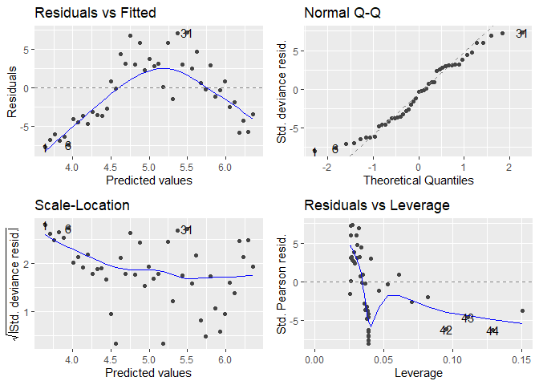

```r
#install.packages("ggfortify")
library(ggfortify)
autoplot(model1)
```

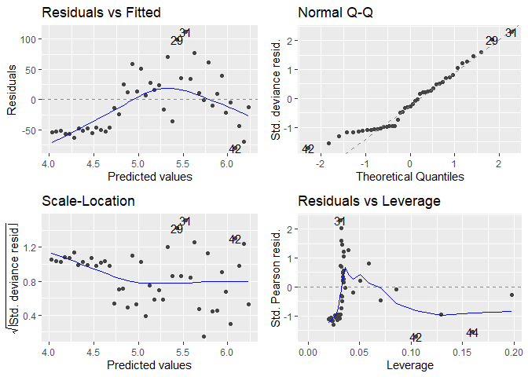

```r
autoplot(model2)
```

In these plots, outliers are also marked with their observation number.

The usual way of extending a model is to include other variables in the model, if there is any, and also check for their two-way interaction. Here in the dataset, we also have information about the quarter of the years. So we include them into the model and check its two-way interaction with the other variate of interest, namely Dates.

## 2.4 (d)

Here we implement what was suggested above. One can look for the best model using ‘step’ command. It eliminates (or add) one term per iteration and check the $AIC$ value and implements the result until all terms are assessed. Here, the output is as follows:

**For the first model**

```r
x2=aids$quarter


model1_2 = glm(y~(x+x2)^2 ,family = poisson(link = 'log'))
model2_2 = glm(y~(x+x2)^2,family = gaussian(link = 'log'))
#####best model
step(model1_2,direction = "backward")
```

```
## Start:  AIC=1122
## y ~ (x + x2)^2
##
##        Df Deviance    AIC
## <none>      810.15 1122.0
## - x:x2  3   819.26 1125.1
```

```
##
## Call:  glm(formula = y ~ (x + x2)^2, family = poisson(link = "log"))
##
## Coefficients:
## (Intercept)            x          x22          x23          x24        x:x22
##  -16.396099     0.242274    -2.383264     0.833175    -0.719737     0.025138
##       x:x23        x:x24
##   -0.008702     0.006907
##
## Degrees of Freedom: 44 Total (i.e. Null);  37 Residual
## Null Deviance:       5738
## Residual Deviance: 810.1     AIC: 1122
```

**For the second model**

```r
step(model2_2,direction = "backward")
```

```
## Start:  AIC=490.94
## y ~ (x + x2)^2
##
##        Df Deviance    AIC
## - x:x2  3    97908 485.53
## <none>       96625 490.94
##
## Step:  AIC=485.53
## y ~ x + x2
##
##        Df Deviance    AIC
## - x2    3   105306 482.81
## <none>       97908 485.53
## - x     1   960977 586.31
##
## Step:  AIC=482.81
## y ~ x
##
##        Df Deviance    AIC
## <none>      105306 482.81
## - x     1   974004 580.92
```

```
##
## Call:  glm(formula = y ~ x, family = gaussian(link = "log"))
##
## Coefficients:
## (Intercept)            x
##    -12.6047       0.2004
##
## Degrees of Freedom: 44 Total (i.e. Null);  43 Residual
## Null Deviance:       974000
## Residual Deviance: 105300    AIC: 482.8
```

We find that for the the first model, including the quarter variable and its two-way interaction with Dates, improves the model as excluding the terms increases the $AIC$. So in mathematical expression the best model is $Cases\sim I(Dates+quarter)^2$ But this isn’t the case with the second model, as including the quarter term isn’t significant and hence the initial model with the equation as $Cases\sim Dates$ is the best model. One can further check the validity of the results obtained above by using some statistical criteria (here $LRT$ test was used). The command ‘drop1’ does so:

For the first model, the output is as the following, showing that no dropping of a term was meaningful:

```r
drop1(model1_2,test="LRT")
```

```
## Single term deletions
##
## Model:
## y ~ (x + x2)^2
##        Df Deviance    AIC    LRT Pr(>Chi)
## <none>      810.15 1122.0
## x:x2    3   819.26 1125.1 9.1147   0.0278 *
## ---
## Signif. codes:  0 '***' 0.001 '**' 0.01 '*' 0.05 '.' 0.1 ' ' 1
```

But for the second model, we eliminate terms whose $p-value$ was above $\alpha = 0.05$. We continue the process until all $p-values$ for terms to be deleted are below $\alpha = 0.05$ :

```r
drop1(model2_2,test="LRT")
```

```
## Single term deletions
##
## Model:
## y ~ (x + x2)^2
##        Df Deviance    AIC scaled dev. Pr(>Chi)
## <none>       96625 490.94
## x:x2    3    97908 485.53     0.59345   0.8979
```

```r
model2_2 = glm(y~(x+x2),family = gaussian(link = 'log'))
drop1(model2_2,test="LRT")
```

```
## Single term deletions
##
## Model:
## y ~ (x + x2)
##        Df Deviance    AIC scaled dev. Pr(>Chi)
## <none>       97908 485.53
## x       1   960977 586.31     102.777   <2e-16 ***
## x2      3   105306 482.81       3.278   0.3507
## ---
## Signif. codes:  0 '***' 0.001 '**' 0.01 '*' 0.05 '.' 0.1 ' ' 1
```

```r
model2_2 = glm(y~(x),family = gaussian(link = 'log'))
drop1(model2_2,test="LRT")
```

```
## Single term deletions
##
## Model:
## y ~ (x)
##        Df Deviance    AIC scaled dev.  Pr(>Chi)
## <none>      105306 482.81
## x       1   974004 580.92      100.11 < 2.2e-16 ***
## ---
## Signif. codes:  0 '***' 0.001 '**' 0.01 '*' 0.05 '.' 0.1 ' ' 1
```

## 2.5 (e)

On the basis of the $AIC$, the $Gaussian$ seems a more plausible fit than the other, since it has a lower $AIC$ value ($482.81$ compared to $1122$).

## 2.6 (f)

From the previous part, we realized that the best model for the $Poisson$ model was the full model (the model including two variables and two-way interactions). So, we use the ‘glm.nb’ command to fit the $Negative Binomial$ model on the full model.The output is shown:

```r
library(MASS)
model3 = glm.nb(y~(x+x2)^2)
step(model3,direction = "backward")
```

```
## Start:  AIC=507.93
## y ~ (x + x2)^2
##
##        Df Deviance    AIC
## - x:x2  3    50.25 502.67
## <none>       49.51 507.93
##
## Step:  AIC=502.67
## y ~ x + x2
##
##        Df Deviance    AIC
## - x2    3   51.236 498.28
## <none>      49.627 502.67
## - x     1  231.716 682.76
##
## Step:  AIC=498.25
## y ~ x
##
##        Df Deviance    AIC
## <none>      49.539 498.25
## - x     1  225.038 671.75
```

```
##
## Call:  glm.nb(formula = y ~ x, init.theta = 4.788444749, link = log)
##
## Coefficients:
## (Intercept)            x
##    -26.0353       0.3493
##
## Degrees of Freedom: 44 Total (i.e. Null);  43 Residual
## Null Deviance:       225
## Residual Deviance: 49.54     AIC: 500.3
```

Using the inference that was mentioned previously, the best model is the one with only Dates as the variate and the quarter variable and the interactions don’t seem significant. The $AIC$ equals $498.25$ for this model, compared to the corresponding values of $1122.0$ and $482.81$ for the $Poisson$ and $Gaussian$ model, respectively. Hence, we conclude that using $NB$ or $Gaussian$ model results in the least $AIC$ value and consequently the best model (the $AIC$ value for the $Gaussian$ model is slightly lower). The coefficients for the $NB$ fit are shown in the output, alongside some other information. The output obtained can further be confirmed using the familiar ‘drop1’ command, introduced previously. It should be used step by step to obtained the best model, since it drops one term at a time.

```r
drop1(model3,test="LRT")
```

```
## Single term deletions
##
## Model:
## y ~ (x + x2)^2
##        Df Deviance    AIC     LRT Pr(>Chi)
## <none>       49.51 507.93
## x:x2    3    50.25 502.67 0.73943   0.8639
```

```r
model3 = glm.nb(y~(x+x2))
drop1(model3,test="LRT")
```

```
## Single term deletions
##
## Model:
## y ~ (x + x2)
##        Df Deviance    AIC     LRT Pr(>Chi)
## <none>      49.627 502.67
## x       1  231.716 682.76 182.089   <2e-16 ***
## x2      3   51.236 498.28   1.609   0.6573
## ---
## Signif. codes:  0 '***' 0.001 '**' 0.01 '*' 0.05 '.' 0.1 ' ' 1
```

```r
model3 = glm.nb(y~(x))
drop1(model3,test="LRT")
```

```
## Single term deletions
##
## Model:
## y ~ (x)
##        Df Deviance    AIC   LRT  Pr(>Chi)
## <none>      49.539 498.25
## x       1  225.038 671.75 175.5 < 2.2e-16 ***
## ---
## Signif. codes:  0 '***' 0.001 '**' 0.01 '*' 0.05 '.' 0.1 ' ' 1
```

These result are consistent with what we obtained using the ‘step’ command.

# 3 3rd Question

Here, we intend to fit a model with survived as the response and age, pclass and gender as the covariates. We also desire to include two-way interactions. Thus we use $I(covariates)^2$ in the glm command.

```r
fit = glm(survived~(age+pclass+gender)^2 , family = binomial , data = titanic)
drop1(fit , test = 'LRT')
```

```
## Single term deletions
##
## Model:
## survived ~ (age + pclass + gender)^2
##               Df Deviance    AIC     LRT  Pr(>Chi)
## <none>             1117.4 1137.4
## age:pclass     2   1126.6 1142.6  9.2138  0.009983 **
## age:gender     1   1121.0 1139.0  3.5548  0.059374 .
## pclass:gender  2   1142.9 1158.9 25.4913 2.915e-06 ***
## ---
## Signif. codes:  0 '***' 0.001 '**' 0.01 '*' 0.05 '.' 0.1 ' ' 1
```

The result of the output guides us toward a simpler model. One can exclude the variable which increases the $AIC$ the least. It expresses in a way if the model without that term is “significantly” different from the model with that term. However since all terms mentioned in the output increase the $AIC$ and this process can progress throughout the model stepwise, we tend to use a statistical test to confirm our results and tell us how far should we get. So on the basis of the $AIC$ and $LRT$ test, here we exclude the interaction between age and gender:

```r
fit = update(fit , survived ~(age+pclass+gender)^2 -age:gender , titanic)
drop1(fit , test = 'LRT')
```

```
## Single term deletions
##
## Model:
## survived ~ age + pclass + gender + age:pclass + pclass:gender
##               Df Deviance    AIC   LRT  Pr(>Chi)
## <none>             1121.0 1139.0
## age:pclass     2   1127.2 1141.2  6.22   0.04459 *
## pclass:gender  2   1167.1 1181.1 46.13 9.614e-11 ***
## ---
## Signif. codes:  0 '***' 0.001 '**' 0.01 '*' 0.05 '.' 0.1 ' ' 1
```

As, here all of terms are significant, we stop the process of dropping and the final model includes all the main effects of age, pclass and gender, alongside two-way interactions age:pclass and pclass:gender.